# Ridge Regression; GCV

Jie Peng| STA 206 Fall 2021

**Ridge regression** is a commonly used method to deal with *severe multicollinearity* (including *perfect collinearity*). Recall that, multicollinearity results in inflated variances of the fitted regression coefficients and poor *interpretability* and *generalizability* of the fitted regression model. One idea is to constrain the fitted regression coefficients to achieve variance reduction, at the expense of introducing some biases. With suitably chosen **tuning parameter**, ridge regression can achieve good **bias-variance trade-off**.

### Ridge estimator

In the following, assume the multiple regression model:
$$Y=X\beta+\epsilon, ~~ E(\epsilon)=0, ~\sigma^2\{\epsilon\}=\sigma^2 \mathbf{I}.$$

The ridge estimator is the minimizer of the **$\ell_2$ penalized least-squares criterion:**
$$Q_\lambda(b)=(Y-Xb)^T (Y-Xb)+\lambda b^T b, ~~~ b \in \mathbb{R}^p,$$
where $\lambda \geq 0$ is the tuning parameter and the term $\lambda b^T b=\lambda ||b||^2_2$ may be viewed as a ``penalty" on the size of the regression coefficients. When $\lambda=0$, there is no penalty and the above is simply the least-squares criterion.

Ridge regression is usually applied to standardized X variables (i.e., centered and scaled) and centered response variable. The purpose is to (i) make the amount of penalty comparable across different regression coefficients (ii) make the regression intercept unaffected by the penalty as we usually do not want to penalize the intercept.

Setting the gradient of $Q_\lambda(\cdot)$ with respect to $b$ to zero gives the *normal equation*:
$$\frac{\partial Q_\lambda(b)}{\partial b}=2X^TX b+2 \lambda b -2 X^T Y=0$$
The solution of the normal equation is the **ridge estimator**:
$$\hat{\beta}_\lambda=(X^T X + \lambda \mathbf{I})^{-1} X^T Y$$
The ordinary least-squares estimator (OLS) $\hat{\beta}_{ols}$ corresponds to $\lambda=0$. On the other hand, when $\lambda>0$, the ridge estimator is shrunk towards zero: $||\hat{\beta}_\lambda||_2 < ||\hat{\beta}_{ols}||_2$. Note that, if both $X$ and $Y$ are centered, the estimated intercept $\hat{\beta}_{0,\lambda}$ will always be zero (and not dependent on $\lambda$).

The ridge estimator is a **biased estimator**:
$$E(\hat{\beta}_\lambda)= (X^T X + \lambda \mathbf{I})^{-1} X^T X \beta,$$
and the amount of bias increases with the increase of $\lambda$.

On the other hand, the variance of the ridge estimator is
$$\sigma^2\{\hat{\beta}_\lambda\}=\sigma^2 (X^T X + \lambda \mathbf{I})^{-1} X^T X (X^T X + \lambda \mathbf{I})^{-1}$$

and the variance decreases with the increase of $\lambda$.

Indeed, there exists a $\lambda \geq 0$ such that the (overall) *mean squared estimation error (msee)* of the regression coefficients

$$\sum_{k=1}^{p-1} msee(\hat{\beta}_{k,\lambda})=\sum_{k=1}^{p-1} var(\hat{\beta}_{k,\lambda})+ bias^2(\hat{\beta}_{k,\lambda}), ~~where ~~ bias(\hat{\beta}_{k,\lambda}):=E(\hat{\beta}_{k,\lambda})-\beta_k$$

is the smallest. Therefore, in theory, ridge regression will always beat the ordinary least-squares regression. However, in practice, we do not know the $\lambda$ that achieves the optimal bias-variance trade-off. Instead, we need to resort to *tuning parameter selection*. One approach is based on the **generalized cross validation (GCV ) criterion** discussed below.

### Generalized cross validation (GCV)

Ridge regression conducts a linear smoothing of $Y$:
$$\hat{Y}_\lambda=X \hat{\beta}_\lambda = X (X^T X + \lambda \mathbf{I})^{-1} X^T Y = S_\lambda Y,$$
where $S_\lambda=X (X^T X + \lambda \mathbf{I})^{-1} X^T$ is referred to as a **smoothing operator/matrix** and the trace of $S_\lambda$ is referred to as the **effective number of parameters**.

Similarly as in ordinary least squares, the **deleted residuals** can be expressed through the corresponding (ordinary) residuals:
$$Y_i-\hat{Y}_{i(i), \lambda}=\frac{Y_i-\hat{Y}_{i,\lambda}}{1-S_{ii,\lambda}}, ~~~i=1,\cdots, n,$$
where $S_{ii, \lambda}$ is the $i$th diagonal element of the smoothing matrix $S_{\lambda}$.

*Notes:*

- The above can be derived in the same way as for OLS.
- The above holds for any linear smoothing of the form: $\hat{Y}=S Y$ that arises from a least squares projection.

The **leave-one-out-cross-validation** criterion is defined as:
$$CV(\lambda)=\frac{1}{n}\sum_{i=1}^n (Y_i-\hat{Y}_{i(i), \lambda})^2=\frac{1}{n}\sum_{i=1}^n (\frac{Y_i-\hat{Y}_{i,\lambda}}{1-S_{ii,\lambda}})^2.$$

The tuning parameter $\lambda$ can then be chosen to minimize $CV(\lambda)$.

Under some settings, $trace(S_\lambda)$ is easier to compute than individual diagonals $S_{ii,\lambda}$, this leads to the **generalized cross validation (GCV)** approximation:
$$GCV(\lambda)=\frac{1}{n}\sum_{i=1}^n (\frac{Y_i-\hat{Y}_{i,\lambda}}{1-trace(S_\lambda)/n})^2,$$
where individual $S_{ii,\lambda}$ is replaced by the average $\frac{1}{n} \sum_{i=1}^n S_{ii,\lambda}=trace(S_\lambda)/n$. In addition to the ease of computation, another advantage of *GCV* is that it alleviates (to some degree) the tendency of *leave-one-out-CV* criterion favoring too small $\lambda$ which leads to *under-smoothing* and *overfitting*.

### Ridge regression: illustration

Here, we use the *bodyfat* data for an illustration:

```r
bodyfat=read.table("bodyfat.txt")
names(bodyfat)=c("X1","X2","X3","Y")
str(bodyfat)
```

```
## 'data.frame':    20 obs. of  4 variables:
##  $ X1: num  19.5 24.7 30.7 29.8 19.1 25.6 31.4 27.9 22.1 25.5 ...
##  $ X2: num  43.1 49.8 51.9 54.3 42.2 53.9 58.5 52.1 49.9 53.5 ...
##  $ X3: num  29.1 28.2 37 31.1 30.9 23.7 27.6 30.6 23.2 24.8 ...
##  $ Y : num  11.9 22.8 18.7 20.1 12.9 21.7 27.1 25.4 21.3 19.3 ...
```

```r
diag(solve(cor(bodyfat[,c("X1", "X2","X3")]))) ##VIFs
```

```
##       X1       X2       X3
## 708.8429 564.3434 104.6060
```

The **variance inflation factors (VIFs)** are very large, indicating severe multicollinearity among $X1, X2, X3$.

We can use the *lm.ridge()* function in the *MASS* library to fit ridge regression on a sequence of $\lambda$. Since the estimated ridge coefficients tend to change a lot as $\lambda$ changes in the vicinity of zero, the $\lambda$ sequence can be chosen to be equally spaced on the *logarithm scale* so $\lambda$ is more densely spaced near zero:

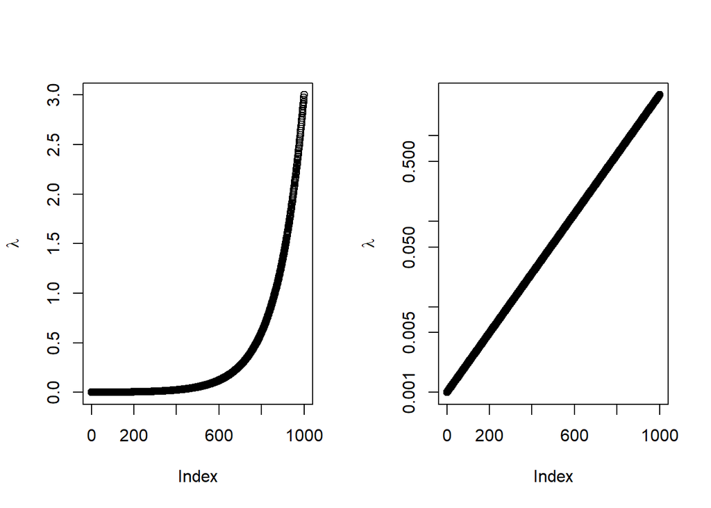

```r
library(MASS)
lambda.s=exp(seq(log(1e-3), log(3), length.out = 1000)) ## sequence of lambda: equally spaced on log-scale
par(mfrow=c(1,2))
plot(lambda.s, ylab=expression(lambda))
plot(lambda.s, ylab=expression(lambda), log="y")
```

```r
par(mfrow=c(1,1))
fit.ridge=lm.ridge(Y~., data=bodyfat,lambda=lambda.s)
summary(fit.ridge)
```

```
##        Length Class  Mode
## coef   3000   -none- numeric
## scales    3   -none- numeric
## Inter     1   -none- numeric
## lambda 1000   -none- numeric
## ym        1   -none- numeric
## xm        3   -none- numeric
## GCV    1000   -none- numeric
## kHKB      1   -none- numeric
## kLW       1   -none- numeric
```

*lm.ridge()* centers and scales the X variables and centers the response variable before fitting the ridge model. The mean ($\bar{X}$) and scales ($\sqrt{\sum_{i=1}^n (X_i-\bar{X})^2/n}$) of the (original) $X$ variables and the mean ($\bar{Y}$) of the (original) response variable are stored in the *xm*, *scales* and *ym* components, respectively. These will be needed to derive the fitted values (on the original scale). The estimated regression coefficients of the X variables are stored in the *coef* component, one row for each $\lambda$. Note that these are not on the original scale, but on the standardized scale.

```r
fit.ridge$xm
```

```
##     X1     X2     X3
## 25.305 51.170 27.620
```

```r
fit.ridge$scales
```

```
##       X1       X2       X3
## 4.896067 5.102068 3.554800
```

```r
fit.ridge$ym
```

```
## [1] 20.195
```

```r
head(t(fit.ridge$coef))
```

```
##                   X1        X2        X3
## 0.001000000 19.98694 -13.47594 -7.299298
## 0.001008047 19.97766 -13.46766 -7.295748
## 0.001016158 19.96832 -13.45933 -7.292174
## 0.001024335 19.95891 -13.45094 -7.288574
## 0.001032577 19.94944 -13.44249 -7.284950
## 0.001040886 19.93990 -13.43398 -7.281300
```

```r
tail(t(fit.ridge$coef))
```

```
##                   X1       X2         X3
## 2.882161055 2.024101 2.211480 -0.3538992
## 2.905352603 2.022289 2.210618 -0.3527527
## 2.928730764 2.020475 2.209741 -0.3516041
## 2.952297039 2.018660 2.208848 -0.3504532
## 2.976052943 2.016844 2.207940 -0.3493002
## 3.000000000 2.015026 2.207016 -0.3481449
```

We can examine how the estimated ridge coefficients change with the tuning parameter $\lambda$ by the so called *ridge trace plot*:

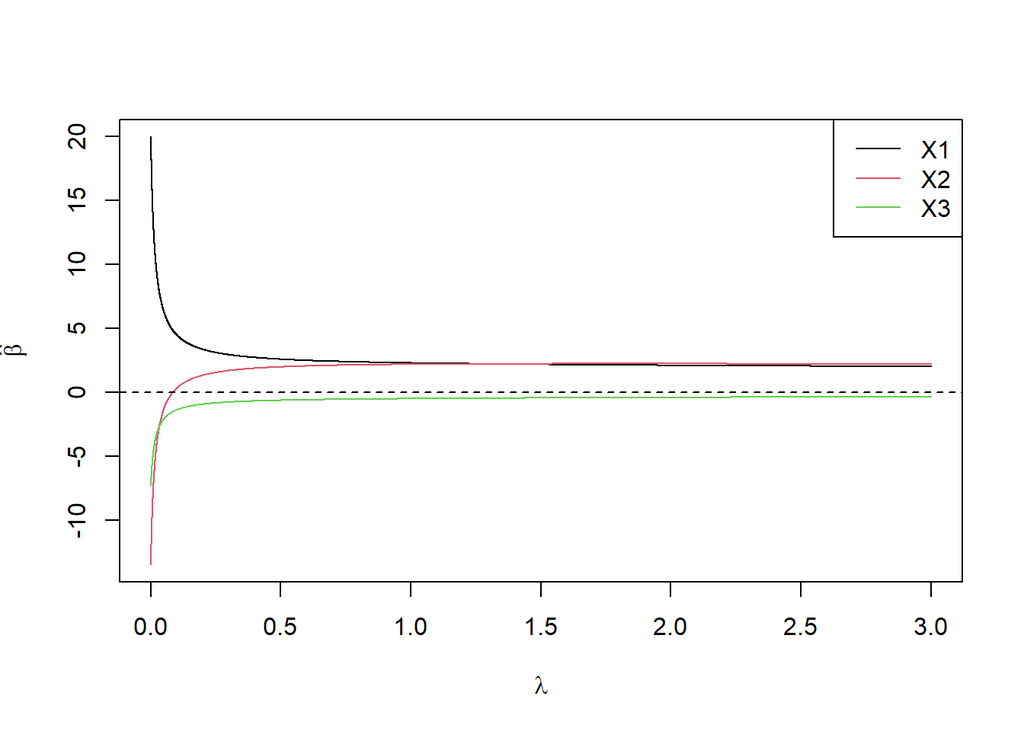

```r
matplot(fit.ridge$lambda, t(fit.ridge$coef), xlab=expression(lambda), ylab=expression(hat(beta)), type='l', lty=1, col=1:3)
legend('topright',legend=rownames(fit.ridge$coef), lty=1, col=1:3)
abline(h=0, lty=2)
```

We can choose the tuning parameter $\lambda$ using the *GCV* criterion. The *GCV* value for each $\lambda$ is stored in the *GCV* component (*Notes: the values stored in the GCV component are $GCV/n$*):

```r
which.min(fit.ridge$GCV)
```

```
## 0.018638874
##         366
```

```r
fit.ridge$coef[, which.min(fit.ridge$GCV)]
```

```
##        X1        X2        X3
## 10.457768 -4.977193 -3.653587
```

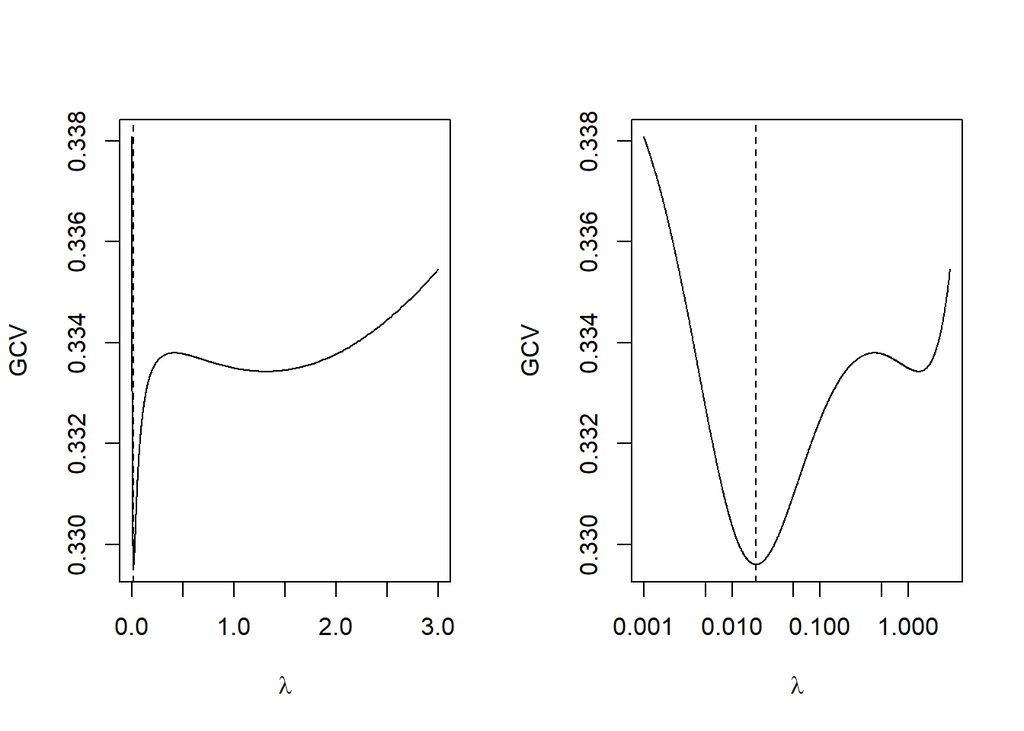

```r
lambda.GCV=fit.ridge$lambda[which.min(fit.ridge$GCV)]
par(mfrow=c(1,2))
plot(fit.ridge$lambda, fit.ridge$GCV, xlab=expression(lambda), ylab="GCV", type='l')
abline(v=lambda.GCV, lty=2)
plot(fit.ridge$lambda, fit.ridge$GCV, xlab=expression(lambda), ylab="GCV", type='l', log="x")
abline(v=lambda.GCV, lty=2)
```

```r
par(mfrow=c(1,1))
```

We can also indicate the *GCV* selection on the *ridge trace plot*. Since the estimated ridge coefficients change more rapidly with $\lambda$ nearer zero, in the *ridge trace plot* we can draw $\lambda$ on the logarithm-scale such that we can see better at the vicinity of zero:

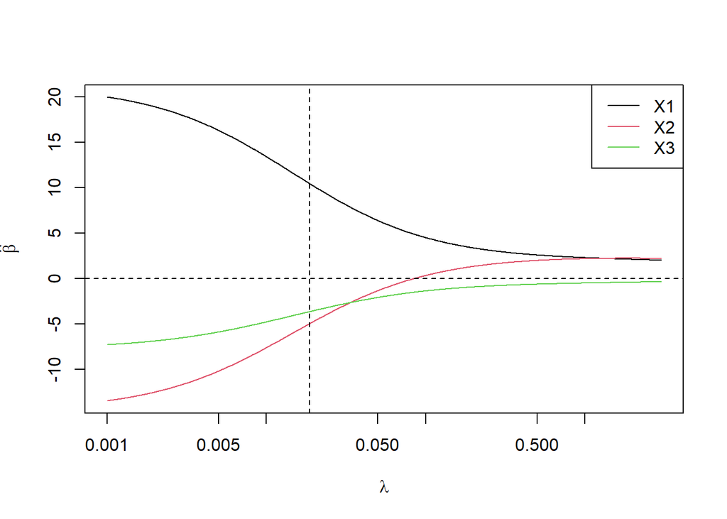

```r
matplot(fit.ridge$lambda, t(fit.ridge$coef), xlab=expression(lambda), ylab=expression(hat(beta)), type='l', lty=1, log="x", col=1:3)
legend('topright',legend=rownames(fit.ridge$coef), lty=1, col=1:3)
abline(h=0, lty=2)
abline(v=lambda.GCV, lty=2)
```

Let’s fit ridge regression directly using the matrix formula and compare with the *lm.ridge()* results:

```r
X=scale(bodyfat[,c("X1","X2","X3")], center=fit.ridge$xm, scale=fit.ridge$scales) ##use the same centering and scaling as in lm.ridge
Y=scale(bodyfat$Y, center=fit.ridge$ym, scale=FALSE)
solve(t(X)%*%X+lambda.GCV*diag(3), t(X))%*%Y ##same as lm.ridge result
```

```
##         [,1]
## X1 10.457768
## X2 -4.977193
## X3 -3.653587
```

```r
fit.ridge$coef[, which.min(fit.ridge$GCV)]
```

```
##        X1        X2        X3
## 10.457768 -4.977193 -3.653587
```

```r
S= X%*%solve(t(X)%*%X+lambda.GCV*diag(3), t(X)) ## the smoothing matrix
S.tr=sum(diag(S)) ## effective number of X variables: less than 3
S.tr
```

```
## [1] 2.436653
```

```r
Yh=S%*%Y ##fitted values
e=Y-Yh ##residuals
n=nrow(bodyfat) ##sample size
mean((e/(1-S.tr/n))^2) ##GCV
```

```
## [1] 6.592093
```

```r
min(fit.ridge$GCV)*n ## "GCV" stored  in lm.ridge() is GCV/n
```

```
## [1] 6.592093
```

The variances of the estimated ridge coefficients are about 5 folds smaller than those of the fitted OLS coefficients:

```r
diag(solve(t(X)%*%X))/diag(solve(t(X)%*%X+lambda.GCV*diag(3), t(X)%*%X)%*%solve(t(X)%*%X+lambda.GCV*diag(3)))
```

```
##       X1       X2       X3
## 5.202856 5.194684 5.024547
```

### Performance evaluation: ridge vs. OLS

In practice, due to lack of knowledge of the *ground truth*, it is often hard to decide how well a method works or whether one method works better than another. For this purpose, we can partition the data into a **training set** used for model building (including model selection or tuning parameter selection) and a **testing set** used **solely** for performance evaluation.

Let’s look at the *meatspec* data from the *faraway* library. This data has fat content along with 100 channel spectrum of absorbances measured on $215$ meat samples. The goal is to build a model using the absorbances measurements (easy to obtain) to predict the fat content (hard to measure through analytical chemistry).

```r
library(faraway)
data(meatspec)
str(meatspec, list.len = 10)
```

```
## 'data.frame':    215 obs. of  101 variables:
##  $ V1  : num  2.62 2.83 2.58 2.82 2.79 ...
##  $ V2  : num  2.62 2.84 2.58 2.82 2.79 ...
##  $ V3  : num  2.62 2.84 2.59 2.83 2.79 ...
##  $ V4  : num  2.62 2.85 2.59 2.83 2.79 ...
##  $ V5  : num  2.62 2.85 2.59 2.83 2.8 ...
##  $ V6  : num  2.62 2.86 2.59 2.83 2.8 ...
##  $ V7  : num  2.62 2.86 2.59 2.83 2.8 ...
##  $ V8  : num  2.62 2.87 2.6 2.84 2.8 ...
##  $ V9  : num  2.63 2.87 2.6 2.84 2.81 ...
##  $ V10 : num  2.63 2.88 2.6 2.84 2.81 ...
##   [list output truncated]
```

```r
names(meatspec)
```

```
##   [1] "V1"   "V2"   "V3"   "V4"   "V5"   "V6"   "V7"   "V8"   "V9"   "V10"
##  [11] "V11"  "V12"  "V13"  "V14"  "V15"  "V16"  "V17"  "V18"  "V19"  "V20"
##  [21] "V21"  "V22"  "V23"  "V24"  "V25"  "V26"  "V27"  "V28"  "V29"  "V30"
##  [31] "V31"  "V32"  "V33"  "V34"  "V35"  "V36"  "V37"  "V38"  "V39"  "V40"
##  [41] "V41"  "V42"  "V43"  "V44"  "V45"  "V46"  "V47"  "V48"  "V49"  "V50"
##  [51] "V51"  "V52"  "V53"  "V54"  "V55"  "V56"  "V57"  "V58"  "V59"  "V60"
##  [61] "V61"  "V62"  "V63"  "V64"  "V65"  "V66"  "V67"  "V68"  "V69"  "V70"
##  [71] "V71"  "V72"  "V73"  "V74"  "V75"  "V76"  "V77"  "V78"  "V79"  "V80"
##  [81] "V81"  "V82"  "V83"  "V84"  "V85"  "V86"  "V87"  "V88"  "V89"  "V90"
##  [91] "V91"  "V92"  "V93"  "V94"  "V95"  "V96"  "V97"  "V98"  "V99"  "V100"
## [101] "fat"
```

```r
summary(diag(solve(cor(meatspec[,1:100])))) ##VIFs summary
```

```
##      Min.   1st Qu.    Median      Mean   3rd Qu.      Max.
## 2.187e+08 1.363e+09 3.132e+09 4.926e+09 7.172e+09 1.834e+10
```

The variance inflation factors (VIFs) are huge, indicating extreme multicollinearity among the 100 X variables.

Let’s first split the data into a training set with 150 samples (~ 70% of the observations) and a testing set with the remaining 65 samples (~ 30% of the observations).

```r
set.seed(1001)
index.tr=sample(nrow(meatspec),150,replace=FALSE) ##70% training; 30% testing
train=meatspec[index.tr,]
test=meatspec[-index.tr, ]
summary(train$fat)
```

```
##    Min. 1st Qu.  Median    Mean 3rd Qu.    Max.
##    0.90    7.20   15.45   18.80   28.98   49.10
```

```r
summary(test$fat)
```

```
##    Min. 1st Qu.  Median    Mean 3rd Qu.    Max.
##    2.00    8.10   13.50   16.62   22.40   47.80
```

Let’s now build an *ordinary least squares (OLS)* model and look at the **root mean squared prediction error (RMSPE)** on training set and testing set, respectively:

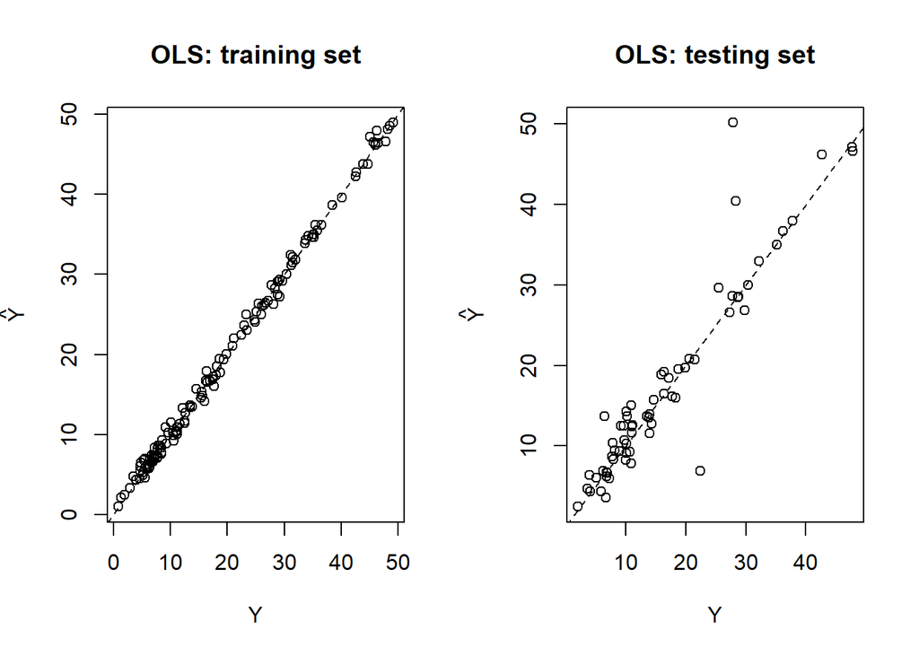

```r
meat.ols=lm(fat~., data=train)
Yh.test.ols=predict(meat.ols, test)

par(mfrow=c(1,2))
plot(train$fat, meat.ols$fitted.values,xlab="Y", ylab=expression(hat(Y)), main="OLS: training set")
abline(0,1, lty=2)
plot(test$fat, Yh.test.ols, xlab="Y", ylab=expression(hat(Y)), main="OLS: testing set")
abline(0,1, lty=2)
```

```r
par(mfrow=c(1,1))

c(sqrt(mean((meat.ols$fitted.values-train$fat)^2)), sqrt(mean((Yh.test.ols-test$fat)^2))) ##OLS: RMSPE on training and testing sets
```

```
## [1] 0.7339363 4.1781203
```

The RMSPE on the testing set is much larger than that on the training set, implying rather severe overfitting by *OLS*.

Now, let’s consider ridge regression and choosing $\lambda$ by *GCV*:

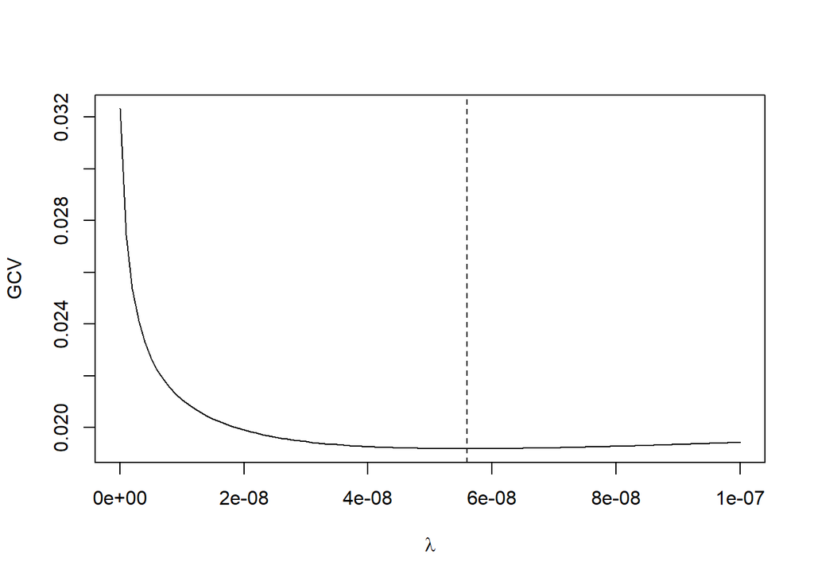

```r
lambda.s=seq(0, 1e-7, 1e-9)
meat.ridge<-lm.ridge(fat~., data=train, lambda=lambda.s)
lambda.GCV=meat.ridge$lambda[which.min(meat.ridge$GCV)]

plot(meat.ridge$lambda, meat.ridge$GCV, xlab=expression(lambda), ylab="GCV", type='l')
abline(v=lambda.GCV, lty=2)
```

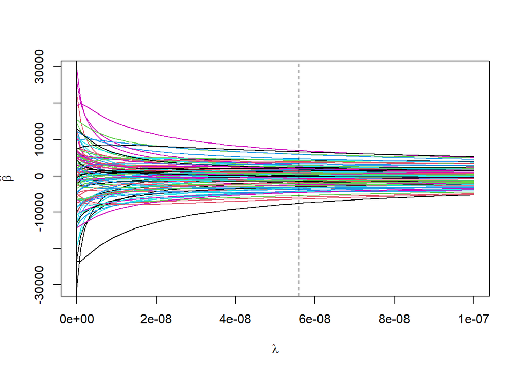

```r
matplot(meat.ridge$lambda, t(meat.ridge$coef), type='l', lty=1, xlab=expression(lambda), ylab=expression(hat(beta)))
abline(v=lambda.GCV, lty=2) ##GCV
abline(v=0, lty=1) ##OLS
```

Let’s derive the RMSPE of the fitted ridge model on the training set and testing set, respectively. Note that, we need to apply the same centering and scaling to the testing set as applied to the training set:

```r
coef.GCV=meat.ridge$coef[, which.min(meat.ridge$GCV)]
summary(meat.ridge$xm)
```

```
##    Min. 1st Qu.  Median    Mean 3rd Qu.    Max.
##   2.806   2.939   3.160   3.189   3.445   3.619
```

```r
summary(meat.ridge$scales)
```

```
##    Min. 1st Qu.  Median    Mean 3rd Qu.    Max.
##  0.4294  0.5063  0.5597  0.5340  0.5642  0.5758
```

```r
meat.ridge$ym
```

```
## [1] 18.804
```

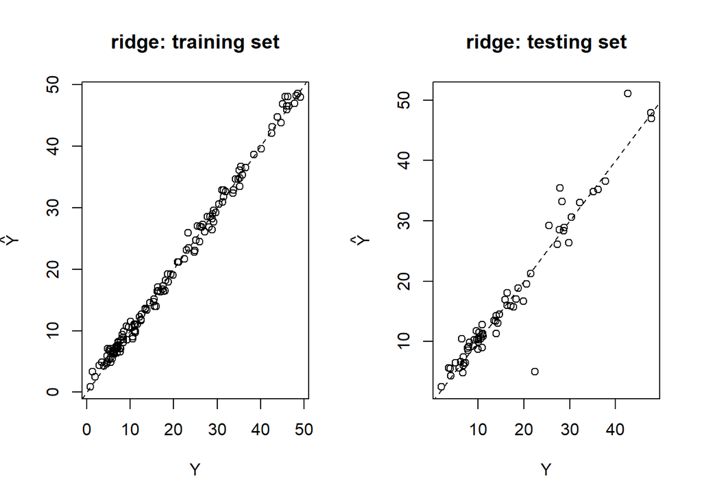

```r
X.train=scale(train[,1:100], center=meat.ridge$xm, scale=meat.ridge$scales)
Yh.train=X.train%*%coef.GCV+meat.ridge$ym
X.test=scale(test[,1:100], center=meat.ridge$xm, scale=meat.ridge$scales)
Yh.test=X.test%*%coef.GCV+meat.ridge$ym

par(mfrow=c(1,2))
plot(train$fat, Yh.train, xlab="Y", ylab=expression(hat(Y)), main="ridge: training set")
abline(0,1, lty=2)
plot(test$fat, Yh.test, xlab="Y", ylab=expression(hat(Y)), main="ridge: testing set")
abline(0,1, lty=2)
```

```r
par(mfrow=c(1,1))

c(sqrt(mean((Yh.train-train$fat)^2)), sqrt(mean((Yh.test-test$fat)^2))) ##ridge: RMSPE on training and testing sets
```

```
## [1] 0.9450213 2.9668577
```

Note that the RMSPE on the training set is larger than that of the OLS. However, the RMSPE on the testing set is smaller than that of the OLS. Moreover, the variances of the estimated ridge coefficients are much smaller than those of the fitted OLS coefficients:

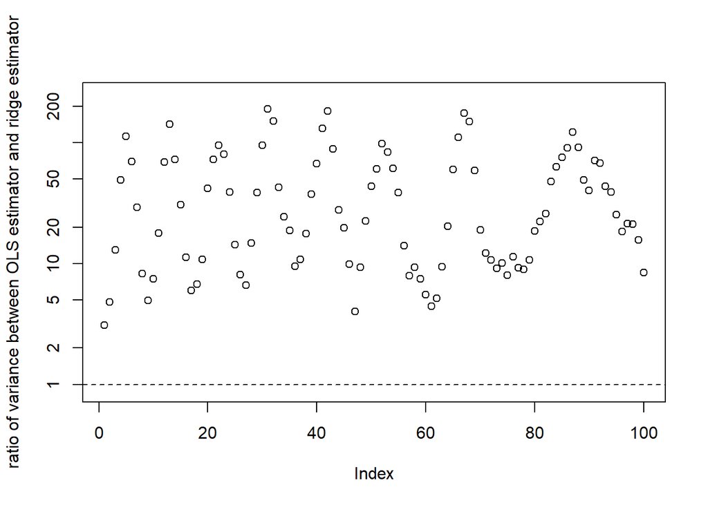

```r
plot(diag(solve(t(X.train)%*%X.train))/diag(solve(t(X.train)%*%X.train+lambda.GCV*diag(100), t(X.train)%*%X.train)%*%solve(t(X.train)%*%X.train+lambda.GCV*diag(100))), ylim=c(0.9, 250),ylab="ratio of variance between OLS estimator and ridge estimator", log="y")
abline(h=1, lty=2)
```

This example demonstrates that compared with *OLS*, ridge regression (with suitably chosen $\lambda$) is less susceptible to overfitting and generalizes better to new observations due to reduced variance. We can also repeat the random split a number of times so that the performances evaluation is not based on a single split:

```r
B=100
rmse.ols<-matrix(0, B,2)
rmse.ridge<-matrix(0, B,2)

for (b in 1:B){
  set.seed(11*b+B) #different seed for each split

  #split data
  index.tr=sample(nrow(meatspec),150,replace=FALSE) ##70% training; 30% testing
  train=meatspec[index.tr,]
  test=meatspec[-index.tr, ]

  #fit ols
  meat.ols=lm(fat~., data=train)
  Yh.test.ols=predict(meat.ols, test)
  rmse.ols[b, ]=c(sqrt(mean((meat.ols$fitted.values-train$fat)^2)), sqrt(mean((Yh.test.ols-test$fat)^2))) ##OLS: RMSPE on training and testing sets

  #fit ridge:
  meat.ridge<-lm.ridge(fat~., data=train, lambda=lambda.s)
  coef.GCV=meat.ridge$coef[, which.min(meat.ridge$GCV)]
  X.train=scale(train[,1:100], center=meat.ridge$xm, scale=meat.ridge$scales)
  Yh.train=X.train%*%coef.GCV+meat.ridge$ym
  X.test=scale(test[,1:100], center=meat.ridge$xm, scale=meat.ridge$scales)
  Yh.test=X.test%*%coef.GCV+meat.ridge$ym
  rmse.ridge[b,]=c(sqrt(mean((Yh.train-train$fat)^2)), sqrt(mean((Yh.test-test$fat)^2))) ##ridge: RMSPE on training and testing sets
}

summary(rmse.ols)
```

```
##        V1               V2
##  Min.   :0.4988   Min.   : 2.085
##  1st Qu.:0.6107   1st Qu.: 3.257
##  Median :0.6484   Median : 4.106
##  Mean   :0.6472   Mean   : 4.428
##  3rd Qu.:0.6891   3rd Qu.: 5.123
##  Max.   :0.7923   Max.   :10.779
```

```r
summary(rmse.ridge)
```

```
##        V1               V2
##  Min.   :0.5637   Min.   :1.678
##  1st Qu.:0.8109   1st Qu.:2.404
##  Median :0.8794   Median :2.997
##  Mean   :0.8678   Mean   :3.194
##  3rd Qu.:0.9605   3rd Qu.:3.698
##  Max.   :1.0500   Max.   :8.400
```

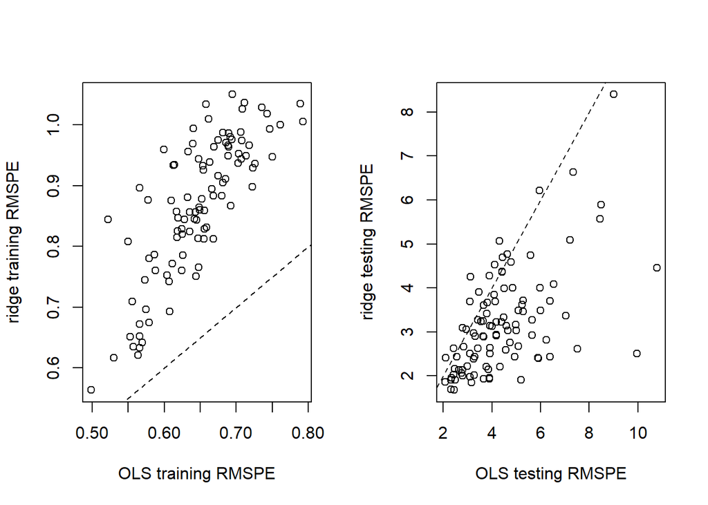

```r
par(mfrow=c(1,2))
plot(rmse.ols[,1], rmse.ridge[,1], xlab="OLS training RMSPE", ylab="ridge training RMSPE")
abline(0,1,lty=2)
plot(rmse.ols[,2], rmse.ridge[,2], xlab="OLS testing RMSPE", ylab="ridge testing RMSPE")
abline(0,1,lty=2)
```

```r
par(mfrow=c(1,1))
```

For all instances, ridge regression has the larger training RMSPE. For most of the instances (but not all), ridge regression has the smaller testing RMSPE.